# Homework week 6 day 3

## 1. Load house sales data and explore it

```r
library(tidyverse)
library(janitor)
library(infer)
library(fastGraph)
```

```r
ames_data <- read_csv("data/ames.csv") %>%
  clean_names()
```

```r
names(ames_data)
```

```
 [1] "order"           "pid"             "ms_sub_class"
 [4] "ms_zoning"       "lot_frontage"    "lot_area"
 [7] "street"          "alley"           "lot_shape"
[10] "land_contour"    "utilities"       "lot_config"
[13] "land_slope"      "neighborhood"    "condition_1"
[16] "condition_2"     "bldg_type"       "house_style"
[19] "overall_qual"    "overall_cond"    "year_built"
[22] "year_remod_add"  "roof_style"      "roof_matl"
[25] "exterior_1st"    "exterior_2nd"    "mas_vnr_type"
[28] "mas_vnr_area"    "exter_qual"      "exter_cond"
[31] "foundation"      "bsmt_qual"       "bsmt_cond"
[34] "bsmt_exposure"   "bsmt_fin_type_1" "bsmt_fin_sf_1"
[37] "bsmt_fin_type_2" "bsmt_fin_sf_2"   "bsmt_unf_sf"
[40] "total_bsmt_sf"   "heating"         "heating_qc"
[43] "central_air"     "electrical"      "x1st_flr_sf"
[46] "x2nd_flr_sf"     "low_qual_fin_sf" "gr_liv_area"
[49] "bsmt_full_bath"  "bsmt_half_bath"  "full_bath"
[52] "half_bath"       "bedroom_abv_gr"  "kitchen_abv_gr"
[55] "kitchen_qual"    "tot_rms_abv_grd" "functional"
[58] "fireplaces"      "fireplace_qu"    "garage_type"
[61] "garage_yr_blt"   "garage_finish"   "garage_cars"
[64] "garage_area"     "garage_qual"     "garage_cond"
[67] "paved_drive"     "wood_deck_sf"    "open_porch_sf"
[70] "enclosed_porch"  "x3ssn_porch"     "screen_porch"
[73] "pool_area"       "pool_qc"         "fence"
[76] "misc_feature"    "misc_val"        "mo_sold"
[79] "yr_sold"         "sale_type"       "sale_condition"
[82] "sale_price"
```

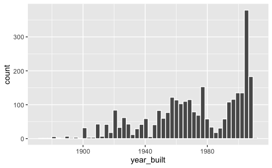

```r
ames_data %>%
  ggplot() +
  aes(x = year_built) +
  scale_y_continuous(labels = scales::comma) +
  geom_histogram(col  = "white", bins = 50)
```

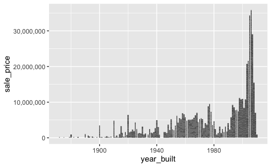

```r
ames_data %>%
  ggplot() +
  aes(x = year_built, y = sale_price) +
  scale_y_continuous(labels = scales::comma) +
  geom_col()
```

```r
NA
```

```r
ames_data %>%
  filter(year_built >= 2000) %>%
  group_by(year_built, bldg_type) %>%
  summarise(count = n()) %>%
  pivot_wider(names_from = bldg_type, values_from = count)
```

| year_built | 1Fam | Duplex | Twnhs | TwnhsE |
| --- | --- | --- | --- | --- |
| 2000 | 34 | 3 | 4 | 7 |
| 2001 | 30 | NA | NA | 5 |
| 2002 | 45 | NA | NA | 2 |
| 2003 | 68 | NA | 4 | 16 |
| 2004 | 66 | NA | 6 | 27 |
| 2005 | 103 | NA | 7 | 32 |
| 2006 | 111 | NA | 2 | 25 |
| 2007 | 96 | NA | 2 | 11 |
| 2008 | 42 | NA | NA | 7 |
| 2009 | 22 | NA | NA | 3 |

[output cut: 1 more lines]

## 2. Plot a histogram of sale_price. Is the distribution normal?

It looks like a reasonable maths for a normal distribution, but there are a lot of values above the line at the lower end of the price scale.

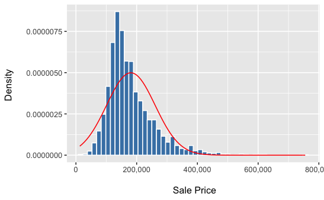

```r
ames_stats <- ames_data %>%
  summarise(
    num = n(),
    mean = mean(sale_price),
    sd = sd(sale_price)
  )

ames_data %>%
  ggplot() +
  aes(x = sale_price) +
  geom_histogram(aes(y = ..density..), col = "white", fill = "Steel Blue", bins = 50)  +
  #facet_wrap(~condition_1)  +
  scale_x_continuous(labels = scales::comma) +
  scale_y_continuous(labels = scales::comma) +
  labs(
    x = "\n Sale Price",
    y = "Density \n"
  ) +
  stat_function(
    fun = dnorm,
    args = list(
      mean = ames_stats$mean,
      sd = ames_stats$sd
    ),
    col = "red"
  )
```

```r
NA
```

## 3. Calculate the population parameter mean of sale_price. Store it in a variable, as we’ll need this value later when we check if each CI contains the parameter value or not.

```r
pop_parameter <- ames_data %>%
  summarise(mean_sale_price = mean(sale_price),
  ) %>%
  pull()
pop_parameter
```

```
[1] 180796.1
```

## 4. Now we are going to:

- take 1000 random samples each of size 100 from sale_price in ames
- create a boostrap sampling distribution of mean(sale_price) from each 100-observation sample (use 1000 reps)
- calculate the 95% CI for each bootstrap distribution
- store the upper and lower bounds of the CI in a tibble called results

Taking code from notes:

```r
results <- tibble()
for (sample_num in 1:1000){

  # get a new 100-observation random sample from ames
  this_sample <- ames_data %>%
    rep_sample_n(size = 100, reps = 1) %>%
    ungroup() %>%
    select(sale_price)

  # create a bootstrap distribution of mean(sale_price)
  # use 1000 reps
  this_bootstrap <- this_sample %>%
    specify(response = sale_price) %>%
    generate(reps = 1000, type = "bootstrap") %>%
    calculate(stat = "mean")

  # get 95% CI for this bootstrap distribution
  this_ci <- this_bootstrap %>%
    get_ci(level = 0.95, type = "percentile")

  # prepare new row for results, storing CI bounds
  this_result <- c(
    sample_num = sample_num,
    lower = this_ci %>%
      pull(lower_ci),
    upper = this_ci %>%
      pull(upper_ci)
  )

  # add this_result to growing tibble of results
  results <- results %>%
    bind_rows(this_result)
}
```

## 5. Pipe results to mutate() to add a new variable popn_param_in_ci which will be TRUE if the population parameter we calculated earlier is between lower and upper, and FALSE otherwise.

| sample_num | lower | upper | popn_param_in_ci |
| --- | --- | --- | --- |
| 1 | 164317.9 | 191649.3 | TRUE |
| 2 | 168427.4 | 202934.2 | TRUE |
| 3 | 174982.0 | 212960.5 | TRUE |
| 4 | 163384.2 | 202681.6 | TRUE |
| 5 | 170157.8 | 193280.9 | TRUE |
| 6 | 158839.2 | 184260.9 | TRUE |
| 7 | 170056.3 | 196902.1 | TRUE |
| 8 | 168460.7 | 198896.5 | TRUE |
| 9 | 154527.0 | 182330.3 | TRUE |
| 10 | 169898.9 | 203002.3 | TRUE |

[output cut: 990 more lines]

## 6.Perform an appropriate summarise() to determine the proportion of CIs that contain the population parameter.

Our confidence level was 95% (equivalent to a proportion of 0.95). Is your proportion close to that value?

```r
 100 * nrow(results %>%
        filter(popn_param_in_ci == TRUE))/nrow(results)
```

```
[1] 94.9
```

## 7. Have a think about what all this means, make a list of any points you don’t understand.

I’d need to go through section 4 again - didn’t really follow what the code was doing.